# Data 180 Final

Data 180, Professor Kennedy

Peter Guma

gumap@dickinson.edu

December 14, 2023

```r
setwd("C:/Users/Peter/Documents/College Documents/DATA 180/Data 180 Peter Guma/DATA-180-PETER-GUMA")
data <- read.csv("loan_default_data_set.csv")
library(dplyr)
library(ggplot2)
```

1. Data wrangling:
1. What is the dimension (shape) of the dataset? How many rows and columns does the data set have?

```r
dim(data)
```

```
## [1] 20000    21
```

2. Report the column names of the data set.

The column names are tot_balance, avg_bal_cards, credit_age, credit_age_good_account, credit_card_age, num_acc_30d_past_due_12_months, num_acc_30d_past_due_6_months, num_mortgage_currently_past_due, tot_amount_currently_past_due, num_inq_12_month, num_card_inq_24_month, num_card_12_month, num_auto_36_month, uti_open_card, pct_over_50_uti, uti_max_credit_line, pct_card_over_50_uti, ind_XYZ, rep_income, rep_education, and Def_ind.

3. Which types of data are there in the dataset? Numeric, categorical, ordinal?

The dataset consists primarily of quantitative (i.e., numeric) data, such as the information associated with the variable tot_balance. However, Def_Ind is a nominal variable: either the user did or did not default, and there is no natural ordering. While we may be tempted to label rep_education as an ordinal variable because there are increasing levels of education, the “other” category has no clear place in that system. I would argue that the dataset contains only numeric and nominal categorical data.

4. Which columns contain missing values and how much (what percent) of those columns are missing?

```r
# is.na(data) #hidden for knit
sum(is.na(data$pct_card_over_50_uti))/20000
```

```
## [1] 0.0979
```

```r
sum(is.na(data$rep_income))/20000
```

```
## [1] 0.07795
```

The only columns which contain missing values are pct_card_over_50_uti and rep_income. The former consists of $9.79\%$ missing values, while the latter column is $7.795\%$ missing.

5. How do you think we should deal with missing values?

One approach to dealing with missing values is to remove those rows altogether. The problem is that doing so means throwing away customer data, which is inadvisable. Removing the columns would be even worse, affecting every customer’s record. Alternatively, we could replace every missing value with a placeholder like NA or 0, but that could impede data analysis. Removing the affected rows is probably our best bet in this scenario.

6. With this data, would you fit a supervised or an unsupervised learning model? Why?

I think a supervised learning model would be better here because we have 20 predictor variables and a clear response variable that we want to predict, namely whether an applicant is likely to default on their account. While an unsupervised learning model could help us understand the structure of our multivariable dataset, going in with a specific goal in mind reduces its utility (that is not our primary goal). Understanding the relationship between any two or more variables is less important than whether a particular combination of variables predicts Def_Ind, which is what supervised learning could get us.

7. For part 2 and 3 drop all rows of the data that contain missing values. Print the dimensions of the resulting data set that has no missing values.

```r
refined_data <- na.omit(data)
dim(refined_data)
```

```
## [1] 16653    21
```

The new data set without missing values has dimensions 16653x21.

2. Data summary statistics:
1. Find the summary statistics of the data set. You can use the summary function from dplyr.

```r
summary(refined_data)
```

```
##   tot_balance     avg_bal_cards     credit_age    credit_age_good_account
##  Min.   :     0   Min.   :    0   Min.   :  0.0   Min.   :  0.0
##  1st Qu.: 92142   1st Qu.:10135   1st Qu.:231.0   1st Qu.:120.0
##  Median :107740   Median :12237   Median :281.0   Median :146.0
##  Mean   :107503   Mean   :12226   Mean   :280.9   Mean   :146.2
##  3rd Qu.:122932   3rd Qu.:14297   3rd Qu.:330.0   3rd Qu.:172.0
##  Max.   :200000   Max.   :25000   Max.   :550.0   Max.   :300.0
##  credit_card_age num_acc_30d_past_due_12_months num_acc_30d_past_due_6_months
##  Min.   :  0.0   Min.   :0.0000                 Min.   :0.00000
##  1st Qu.:242.0   1st Qu.:0.0000                 1st Qu.:0.00000
##  Median :285.0   Median :0.0000                 Median :0.00000
##  Mean   :285.4   Mean   :0.1579                 Mean   :0.02936
##  3rd Qu.:330.0   3rd Qu.:0.0000                 3rd Qu.:0.00000
##  Max.   :550.0   Max.   :5.0000                 Max.   :2.00000
##  num_mortgage_currently_past_due tot_amount_currently_past_due
##  Min.   :0.0000                  Min.   :    0.0
##  1st Qu.:0.0000                  1st Qu.:    0.0
##  Median :0.0000                  Median :    0.0
##  Mean   :0.0299                  Mean   :  354.2
##  3rd Qu.:0.0000                  3rd Qu.:    0.0
##  Max.   :1.0000                  Max.   :35000.0
##  num_inq_12_month  num_card_inq_24_month num_card_12_month num_auto_.36_month
##  Min.   : 0.0000   Min.   : 0.000        Min.   :0.0000    Min.   :0.000
##  1st Qu.: 0.0000   1st Qu.: 0.000        1st Qu.:0.0000    1st Qu.:0.000
##  Median : 0.0000   Median : 0.000        Median :0.0000    Median :0.000
##  Mean   : 0.6133   Mean   : 1.044        Mean   :0.2723    Mean   :0.165
##  3rd Qu.: 1.0000   3rd Qu.: 1.000        3rd Qu.:1.0000    3rd Qu.:0.000
##  Max.   :10.0000   Max.   :18.000        Max.   :3.0000    Max.   :2.000
##  uti_open_card    pct_over_50_uti  uti_max_credit_line pct_card_over_50_uti
##  Min.   :0.0000   Min.   :0.0000   Min.   :0.0000      Min.   :0.0000
##  1st Qu.:0.4048   1st Qu.:0.4011   1st Qu.:0.3778      1st Qu.:0.4643
##  Median :0.4909   Median :0.4855   Median :0.4649      Median :0.5518
##  Mean   :0.4914   Mean   :0.4842   Mean   :0.4653      Mean   :0.5511
##  3rd Qu.:0.5783   3rd Qu.:0.5679   3rd Qu.:0.5541      3rd Qu.:0.6384
##  Max.   :1.0000   Max.   :0.9294   Max.   :1.0000      Max.   :1.0000
##     ind_XYZ         rep_income     rep_education         Def_ind
##  Min.   :0.0000   Min.   : 20000   Length:16653       Min.   :0.0000
##  1st Qu.:0.0000   1st Qu.:143751   Class :character   1st Qu.:0.0000
##  Median :0.0000   Median :166630   Mode  :character   Median :0.0000
##  Mean   :0.2487   Mean   :166504                      Mean   :0.1019
##  3rd Qu.:0.0000   3rd Qu.:189020                      3rd Qu.:0.0000
##  Max.   :1.0000   Max.   :300000                      Max.   :1.0000
```

2. Based on the mean, mode, and median, is “num_card_inq_24_month” bell shaped, left, right skewed? How about “tot_amount_currently_past_due”? “credit_age”?

3. Plot a histogram of the variables in b above. Do the shapes of the histograms confirm the skewness you found in b?

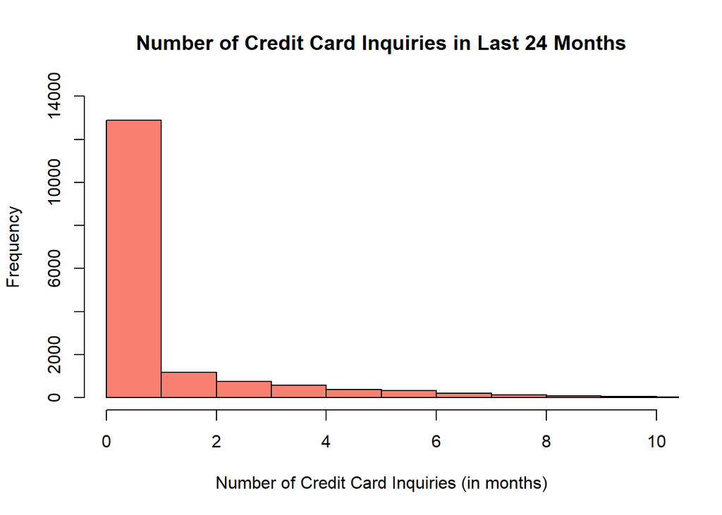

```r
hist(refined_data$num_card_inq_24_month, xlab="Number of Credit Card Inquiries (in months)", main="Number of Credit Card Inquiries in Last 24 Months", xlim=c(0,10), ylim=c(0,14000), col="salmon")
```

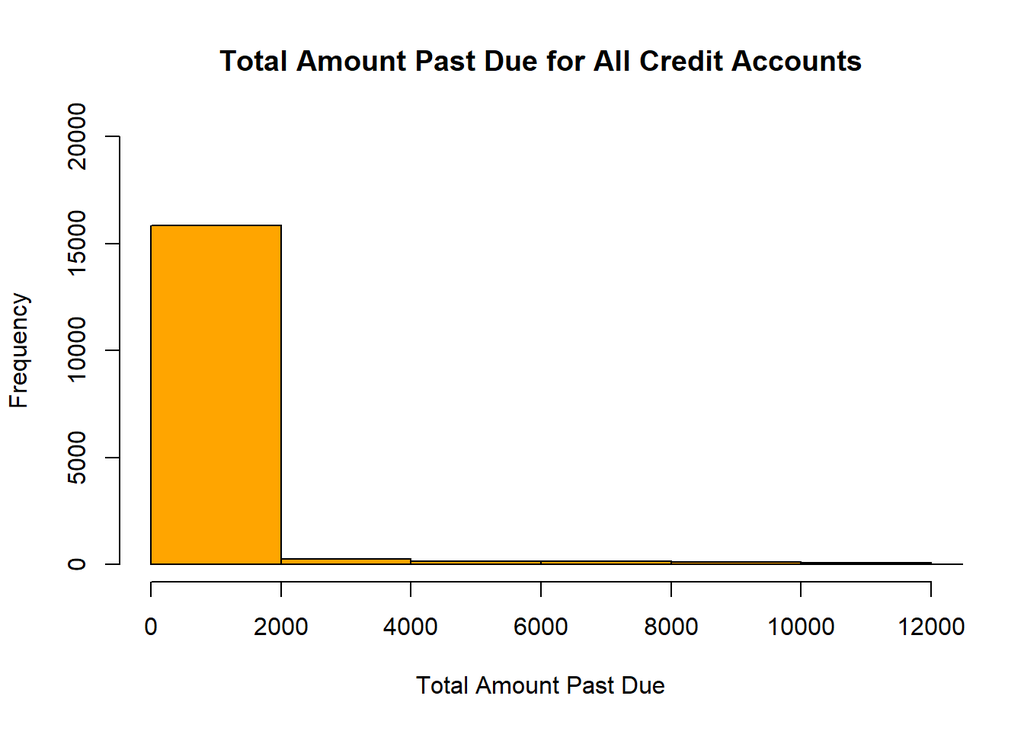

```r
hist(refined_data$tot_amount_currently_past_due, xlab="Total Amount Past Due", main="Total Amount Past Due for All Credit Accounts", xlim=c(0,12000), ylim=c(0,20000), col="orange")
```

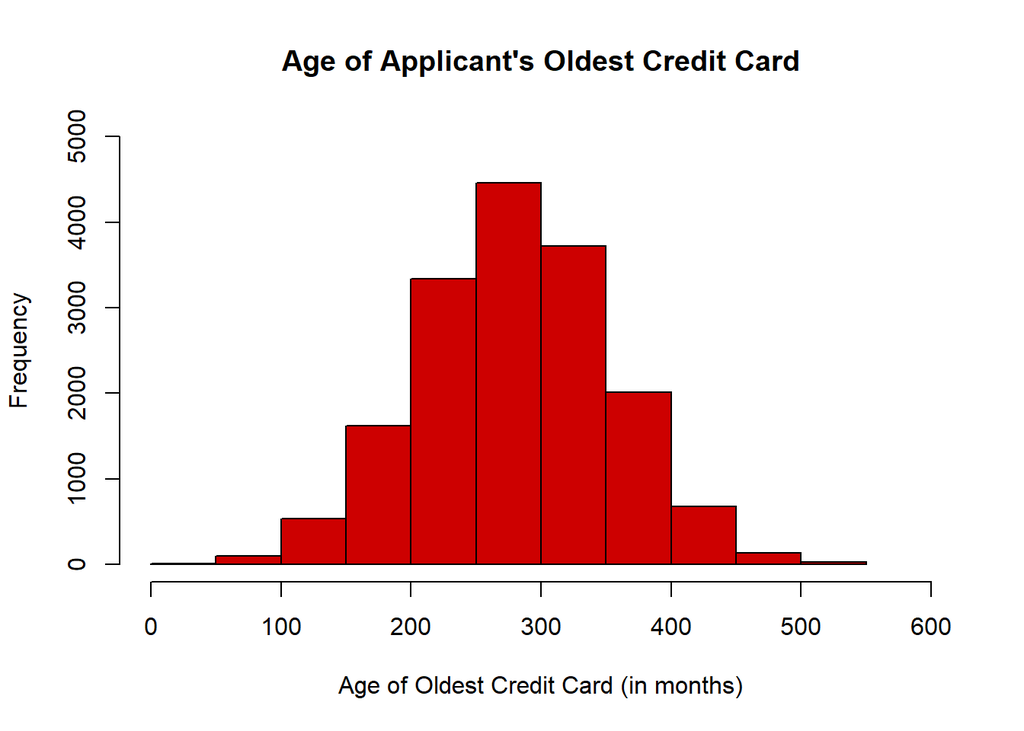

```r
hist(refined_data$credit_age, xlab="Age of Oldest Credit Card (in months)", main="Age of Applicant's Oldest Credit Card", xlim=c(0,600), ylim=c(0,5000), col="red3")
```

4. How would your convert the “rep_education” column into numerical data? Name two ways.

To convert the rep_education column into numerical data, I could assign an integer ranging from 0 to 3 to each category. What level of education maps to a given integer is flexible, though I would probably go in order of increasing education and designate “other” as a 3 because it could conceivably be at the same level as or higher than a standard graduate degree. In any case, it would probably make sense to put “high-school or below” at the bottom, at 0.

Alternatively, I would consider spacing out the numbers more in case there is something specific I want to model that correlates strongly with education level. High school could be a 0, a college degree could bring a customer up to a 3, and a graduate degree would be around a 5. While I am not sure where I would place “other”, the point is that a larger number for rep_education could better predict something like earnings than evenly spaced categories. The approach would be the same as my first method, but the numbers would differ. Still, the first method is probably better for exploratory data analysis.

3. Data Visualization: For every graph in this section, remember to label your axes and to include a title. Feel free to play around with graphics and parameters. Have fun and explore!
1. Plot a bar graph for the “Def_Ind” column and describe it.

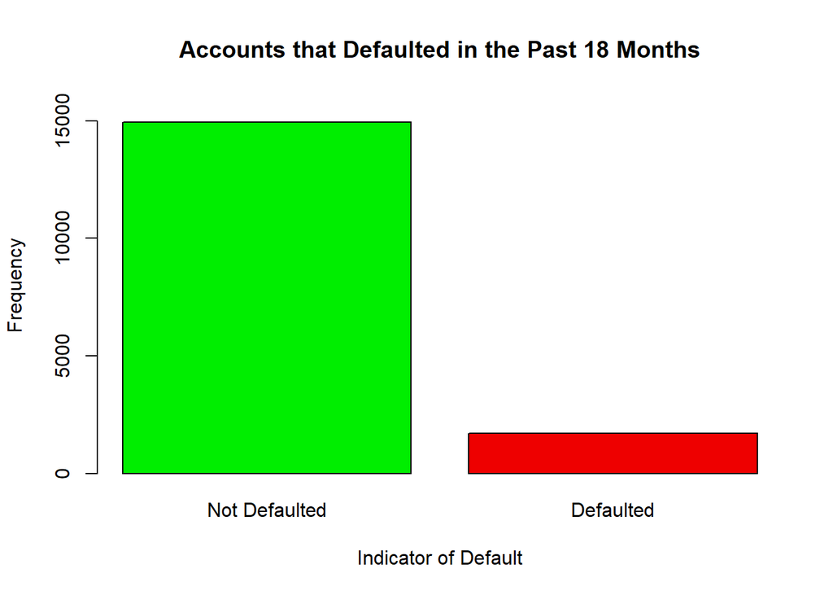

```r
barplot(table(refined_data$Def_ind), names.arg=c("Not Defaulted", "Defaulted"), xlab="Indicator of Default", ylab="Frequency", main="Accounts that Defaulted in the Past 18 Months", ylim=c(0,16000), col=c("green2","red2"))
```

2. Plot a bar graph for the “rep_education” column and describe it.

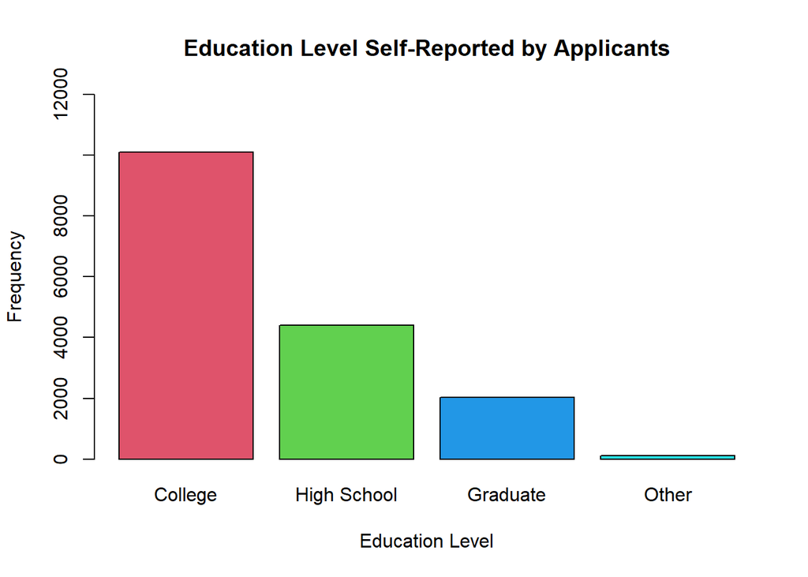

```r
barplot(sort(table(refined_data$rep_education), decreasing=TRUE), names.arg=c("College", "High School", "Graduate", "Other"), xlab="Education Level", ylab="Frequency", main="Education Level Self-Reported by Applicants", ylim=c(0,12000), col=c(2,3,4,5))
```

As we see in the graph, approximately 10000 applicants have received a college education, followed by 4000 with a high-school diploma or less, 2000 with a graduate degree, and a tiny percentage with another education level. Bank XYZ may want to tailor its marketing to high-schoolers and graduate degree holders to increase its market share of those demographics. However, this information on its own is not particularly helpful for deciding which new applicants to accept. While the majority of people did not default, and the majority of applicants reported their education level as “college”, being in any particular demographic group should not qualify or disqualify any applicant without considering their other credentials.

3. Plot a histogram of the “rep_income” variable.

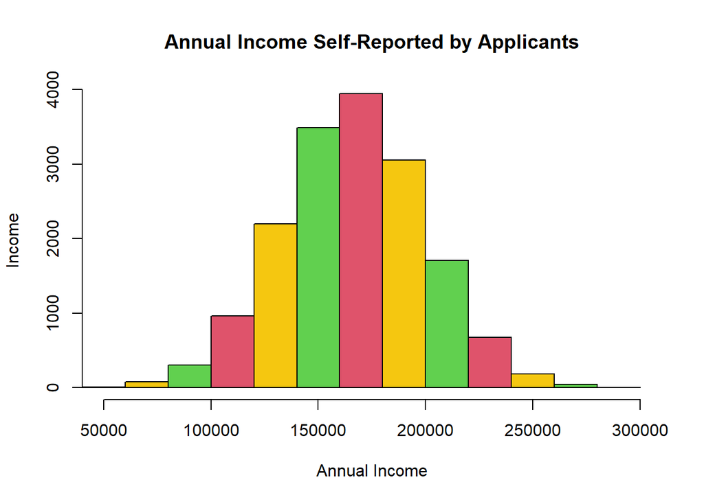

```r
hist(refined_data$rep_income, xlab="Annual Income", ylab="Income", main="Annual Income Self-Reported by Applicants", xlim=c(50000, 300000), col=c(19,26,31))
```

4. Plot a boxplot of the “tot_balance” variable. Using the box plot report the five number summary of the variable? Are there any outliers for this variable?

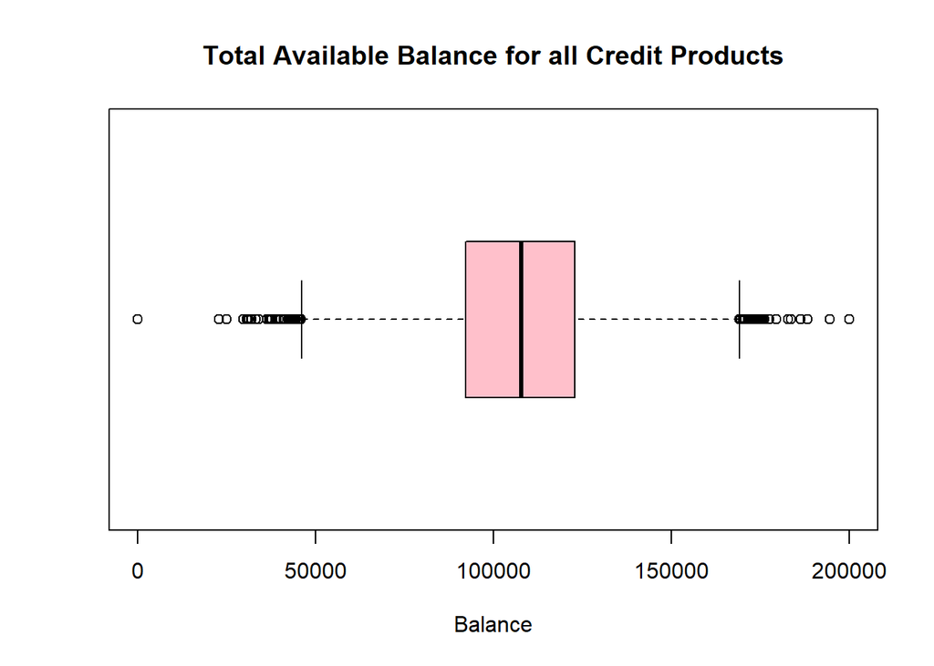

```r
boxplot(refined_data$tot_balance, horizontal=TRUE, xlab="Balance", main="Total Available Balance for all Credit Products", col="pink")
```

```r
# Add ylim=c(50000,175000) as an argument to zoom in
```

According to the box plot, the minimum is around 45000, the first quartile is a bit over 90000, the median is 110000, the third quartile is 120000, and the maximum is around 170000 (all approximations). There are quite a few outliers beyond the left and right whiskers, ranging from about 25000 to 200000 (in addition to however many customers have zero available balance).